# Performance comparison with other functional diversity packages

This vignette presents some performance tests ran between `fundiversity` and other functional diversity packages. Note that to avoid the dependency on other packages, this vignette is [**pre-computed**](https://ropensci.org/technotes/2019/12/08/precompute-vignettes/).

# Other packages to compute FD indices

## Main functions

**`FD::dbFD()`** is probably the most known function to compute functional diversity indices. It comes from the `FD` package proposed by Laliberté, Legendre, and Shipley (2014). It can compute many indices: functional richness, Rao’s quadratic entropy, community-weighted mean, functional divergence, functional dispersion, and functional group richness. This swiss-army knife of functional diversity indices has many options and compute several indices in a single run.

**`adiv::QE()`** comes from the `adiv` package which proposes a toolkit to analyze biodiversity (Pavoine 2020). This function computes Rao’s quadratic entropy.

## Benchmark between packages

We will now benchmark the functions included in `fundiversity` with the corresponding function in other packages using the `microbenchmark::microbenchmark()` function.

```r
tictoc::tic()
library(fundiversity)
data("traits_birds", package = "fundiversity")
data("site_sp_birds", package = "fundiversity")

dist_traits_birds <- dist(traits_birds)
```

With the fairly small (~220 species, 8 sites, 4 traits) provided dataset in `fundiversity`:

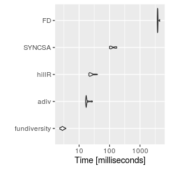

Performance comparison in computing Rao’s quadratic entropy between `fundiversity` and other packages

```r
pkg_bench <- microbenchmark::microbenchmark(
  fundiversity = {
    fundiversity::fd_raoq(traits = NULL, site_sp_birds, dist_traits_birds)
  },
  adiv = {
    adiv::QE(site_sp_birds, dis = dist_traits_birds)
  },
  hillR = {
    hillR::hill_func(site_sp_birds, dist_traits_birds, traits_as_is = TRUE)[1, ]
  },
  SYNCSA = {
    SYNCSA::rao.diversity(site_sp_birds,
                          phylodist = as.matrix(dist_traits_birds),
                          standardize = FALSE)$PhyRao
  },
  FD = {
    suppressMessages(
      FD::dbFD(x = dist_traits_birds, a = site_sp_birds, stand.x = FALSE,
               calc.FRic = TRUE, calc.CWM = FALSE, calc.FDiv = FALSE,
               calc.FGR = FALSE, m = "max", stand.FRic = FALSE,
               messages = FALSE))
  },
  times = 30
)

ggplot2::autoplot(pkg_bench)
```

```r
pkg_bench
```

```
#> Unit: milliseconds
#>          expr         min          lq       mean      median          uq        max neval cld
#>  fundiversity    2.339107    2.679755    2.86275    2.844036    3.091743    3.67650    30 a
#>          adiv   16.337660   16.943282   18.43515   17.246230   17.951186   27.34455    30 a
#>         hillR   20.962736   21.871550   25.47572   23.721294   26.186873   39.93380    30 a
#>        SYNCSA   99.656210  107.666750  127.10731  111.566921  153.724931  172.40455    30  b
#>            FD 3707.559225 3757.548520 3824.34691 3803.413993 3846.068130 4452.37957    30   c
```

# Benchmark within `fundiversity`

We now proceed to the performance evaluation of functions within `fundiversity` with datasets of increasing sizes.

## Increasing the number of species

```r
make_more_sp <- function(n) {
  traits <- do.call(rbind, replicate(n, traits_birds, simplify = FALSE))
  row.names(traits) <- paste0("sp", seq_len(nrow(traits)))

  site_sp <- do.call(cbind, replicate(n, site_sp_birds, simplify = FALSE))
  colnames(site_sp) <- paste0("sp", seq_len(ncol(site_sp)))

  list(tr = traits, si = site_sp)
}

null_sp_1000   <- make_more_sp(5)
null_sp_10000  <- make_more_sp(50)
null_sp_100000 <- make_more_sp(500)
```

### Functional Richness

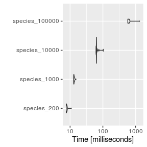

Performance comparison of `fd_fric()` with increasing number of species.

```r
bench_sp_fric <- microbenchmark::microbenchmark(
  species_200    = fd_fric(     traits_birds, site_sp_birds),
  species_1000   = fd_fric(  null_sp_1000$tr, null_sp_1000$si),
  species_10000  = fd_fric( null_sp_10000$tr, null_sp_10000$si),
  species_100000 = fd_fric(null_sp_100000$tr, null_sp_100000$si),
  times = 30
)

ggplot2::autoplot(bench_sp_fric)
```

```r
bench_sp_fric
```

```
#> Unit: milliseconds
#>            expr        min         lq       mean     median         uq        max neval cld
#>     species_200   7.615313   7.702048   7.954415   7.826739   8.018565   10.91064    30 a
#>    species_1000  12.885544  12.981276  13.316684  13.126898  13.553409   15.11672    30 a
#>   species_10000  61.719295  62.966299  65.274608  63.521071  63.810353  102.85792    30  b
#>  species_100000 576.763170 586.160198 633.346018 617.814287 631.369788 1319.90990    30   c
```

### Functional Divergence

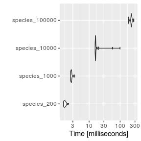

Performance comparison of `fd_fdiv()` with increasing number of species.

```r
bench_sp_fdiv <- microbenchmark::microbenchmark(
  species_200    = fd_fdiv(     traits_birds, site_sp_birds),
  species_1000   = fd_fdiv(  null_sp_1000$tr, null_sp_1000$si),
  species_10000  = fd_fdiv( null_sp_10000$tr, null_sp_10000$si),
  species_100000 = fd_fdiv(null_sp_100000$tr, null_sp_100000$si),
  times = 30
)

ggplot2::autoplot(bench_sp_fdiv)
```

```r
bench_sp_fdiv
```

```
#> Unit: milliseconds
#>            expr        min         lq       mean     median         uq        max neval cld
#>     species_200   1.500200   1.570514   1.687893   1.655283   1.750778   2.208015    30 a
#>    species_1000   2.500834   2.595685   2.734870   2.669771   2.734597   3.437590    30 a
#>   species_10000  15.612044  15.944394  20.622579  16.172466  16.468177  99.368520    30  b
#>  species_100000 185.417109 221.556751 225.694270 229.597922 234.594519 277.369051    30   c
```

### Rao’s Quadratric Entropy

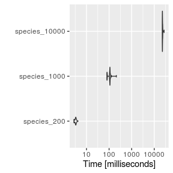

Performance comparison of `fd_raoq()` with increasing number of species.

```r
bench_sp_raoq <- microbenchmark::microbenchmark(
  species_200    = fd_raoq(     traits_birds, site_sp_birds),
  species_1000   = fd_raoq(  null_sp_1000$tr, null_sp_1000$si),
  species_10000  = fd_raoq( null_sp_10000$tr, null_sp_10000$si),
  times = 30
)

ggplot2::autoplot(bench_sp_raoq)
```

```r
bench_sp_raoq
```

```
#> Unit: milliseconds
#>           expr          min           lq         mean       median           uq          max neval cld
#>    species_200     2.763427     2.890691     3.259555     3.326868     3.362139     4.193017    30  a
#>   species_1000    80.003731   105.398890   106.636548   108.655809   109.445712   210.281101    30  a
#>  species_10000 22704.001464 22865.302018 23321.980942 23107.372466 23433.746372 27386.876071    30   b
```

### Functional Evenness

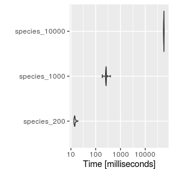

Performance comparison of `fd_feve()` with increasing number of species.

```r
bench_sp_feve <- microbenchmark::microbenchmark(
  species_200    = fd_feve(     traits_birds, site_sp_birds),
  species_1000   = fd_feve(  null_sp_1000$tr, null_sp_1000$si),
  species_10000  = fd_feve( null_sp_10000$tr, null_sp_10000$si),
  times = 30
)

ggplot2::autoplot(bench_sp_feve)
```

```r
bench_sp_feve
```

```
#> Unit: milliseconds
#>           expr         min          lq        mean      median          uq         max neval cld
#>    species_200    13.17559    13.77455    14.41294    14.23335    14.57117    19.03587    30  a
#>   species_1000   184.70177   254.66965   260.40187   261.08829   263.76563   391.38994    30  a
#>  species_10000 54499.29784 55580.32678 56205.03514 56369.63482 56798.12055 57694.77626    30   b
```

### Comparing between indices

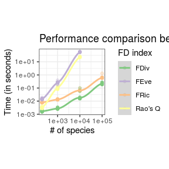

Performance comparison between functions for distinct indices in `fundiversity` with increasing number of species. Smoothed trend lines and standard error enveloppes ares shown.

```r
all_bench_sp <- list(fric = bench_sp_fric,
                     fdiv = bench_sp_fdiv,
                     raoq = bench_sp_raoq,
                     feve = bench_sp_feve) %>%
  bind_rows(.id = "fd_index") %>%
  mutate(n_sp = gsub("species_", "", expr) %>%
           as.numeric())

all_bench_sp %>%
  ggplot(aes(n_sp, time * 1e-9, color = fd_index)) +
  geom_point(alpha = 1/3) +
  geom_smooth() +
  scale_x_log10() +
  scale_y_log10() +
  scale_color_brewer(type = "qual",
                     labels = c(fric = "FRic", fdiv = "FDiv", raoq = "Rao's Q",
                                feve = "FEve")) +
  labs(title = "Performance comparison between indices",
       x = "# of species", y = "Time (in seconds)",
       color = "FD index") +
  theme_bw() +
  theme(aspect.ratio = 1)
```

## Increasing the number of sites

```r
make_more_sites <- function(n) {
  site_sp <- do.call(rbind, replicate(n, site_sp_birds, simplify = FALSE))
  rownames(site_sp) <- paste0("s", seq_len(nrow(site_sp)))

  site_sp
}

site_sp_100   <- make_more_sites(12)
site_sp_1000  <- make_more_sites(120)
site_sp_10000 <- make_more_sites(1200)
```

### Functional Richness

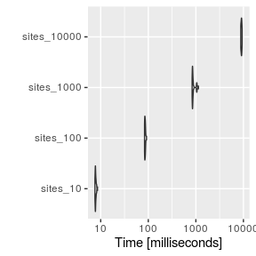

Performance comparison of `fd_fric()` with increasing number of sites.

```r
bench_sites_fric = microbenchmark::microbenchmark(
  sites_10    = fd_fric(traits_birds, site_sp_birds),
  sites_100   = fd_fric(traits_birds, site_sp_100),
  sites_1000  = fd_fric(traits_birds, site_sp_1000),
  sites_10000 = fd_fric(traits_birds, site_sp_10000),
  times = 30
)

ggplot2::autoplot(bench_sites_fric)
```

```r
bench_sites_fric
```

```
#> Unit: milliseconds
#>         expr         min          lq        mean      median          uq         max neval  cld
#>     sites_10    7.565473    7.702472    7.827105    7.750489    7.905575    8.564705    30 a
#>    sites_100   83.450716   84.305859   85.727895   85.233143   86.775621   91.819463    30  b
#>   sites_1000  834.575849  850.001429  897.579910  854.871171  879.858287 1130.871650    30   c
#>  sites_10000 8791.171667 8938.011568 9073.600229 9068.465019 9207.476917 9396.389048    30    d
```

### Functional Divergence

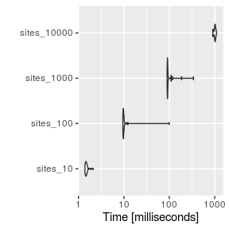

Performance comparison of `fd_fdiv()` with increasing number of sites.

```r
bench_sites_fdiv = microbenchmark::microbenchmark(
  sites_10    = fd_fdiv(traits_birds, site_sp_birds),
  sites_100   = fd_fdiv(traits_birds, site_sp_100),
  sites_1000  = fd_fdiv(traits_birds, site_sp_1000),
  sites_10000 = fd_fdiv(traits_birds, site_sp_10000),
  times = 30
)

ggplot2::autoplot(bench_sites_fdiv)
```

```r
bench_sites_fdiv
```

```
#> Unit: milliseconds
#>         expr        min         lq       mean      median          uq         max neval cld
#>     sites_10   1.385996   1.436161   1.514947    1.472574    1.539582    2.115742    30 a
#>    sites_100   9.497658   9.642636  12.929336    9.756676    9.988263   99.860745    30 a
#>   sites_1000  89.462678  90.728186 105.017476   91.645153   92.934691  341.290685    30  b
#>  sites_10000 905.237931 925.024218 998.032305 1014.421967 1028.780041 1101.515461    30   c
```

### Rao’s Quadratic Entropy

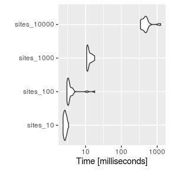

Performance comparison of `fd_raoq()` with increasing number of sites.

```r
bench_sites_raoq = microbenchmark::microbenchmark(
  sites_10    = fd_raoq(traits = NULL, site_sp_birds, dist_traits_birds),
  sites_100   = fd_raoq(traits = NULL, site_sp_100,   dist_traits_birds),
  sites_1000  = fd_raoq(traits = NULL, site_sp_1000,  dist_traits_birds),
  sites_10000 = fd_raoq(traits = NULL, site_sp_10000, dist_traits_birds),
  times = 30
)

ggplot2::autoplot(bench_sites_raoq)
```

```r
bench_sites_raoq
```

```
#> Unit: milliseconds
#>         expr        min         lq       mean     median         uq         max neval cld
#>     sites_10   2.360504   2.503792   2.716836   2.693231   2.949578    3.369483    30  a
#>    sites_100   3.029248   3.201675   4.217164   3.372607   4.027594   18.055758    30  a
#>   sites_1000  10.783140  11.139077  12.710237  11.578792  13.957909   18.007539    30  a
#>  sites_10000 341.295425 397.933927 495.800959 458.589577 511.140683 1263.525121    30   b
```

### Functional Evenness

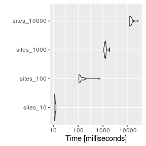

Performance comparison of `fd_feve()` with increasing number of sites

```r
bench_sites_feve = microbenchmark::microbenchmark(
  sites_10    = fd_feve(traits = NULL, site_sp_birds, dist_traits_birds),
  sites_100   = fd_feve(traits = NULL, site_sp_100,   dist_traits_birds),
  sites_1000  = fd_feve(traits = NULL, site_sp_1000,  dist_traits_birds),
  sites_10000 = fd_feve(traits = NULL, site_sp_10000, dist_traits_birds),
  times = 30
)

ggplot2::autoplot(bench_sites_feve)
```

```r
bench_sites_feve
```

```
#> Unit: milliseconds
#>         expr         min          lq        mean      median          uq         max neval cld
#>     sites_10    10.82708    11.07722    11.53401    11.42092    11.75125    12.79826    30 a
#>    sites_100   107.34637   110.09369   146.57728   114.68564   157.27761   756.37596    30 a
#>   sites_1000  1082.09198  1168.72524  1278.28016  1255.70507  1273.23958  1849.12083    30  b
#>  sites_10000 11486.18977 11579.98002 13306.97820 12755.76890 13730.50375 25937.46769    30   c
```

### Comparing between indices

```r
all_bench_sites <- list(fric = bench_sites_fric,
                        fdiv = bench_sites_fdiv,
                        raoq = bench_sites_raoq,
                        feve = bench_sites_feve) %>%
  bind_rows(.id = "fd_index") %>%
  mutate(n_sites = gsub("sites", "", expr) %>%
           as.numeric())
```

[figure not shown]

# References

Chao, Anne, Chun-Huo Chiu, and Lou Jost. 2014. “Unifying Species Diversity, Phylogenetic Diversity, Functional Diversity, and Related Similarity and Differentiation Measures Through Hill Numbers.” *Annual Review of Ecology, Evolution, and Systematics* 45 (1): 297–324. https://doi.org/10.1146/annurev-ecolsys-120213-091540.

Debastiani, Vanderlei J., and Valério D. Pillar. 2012. “SYNCSAR Tool for Analysis of Metacommunities Based on Functional Traits and Phylogeny of the Community Components.” *Bioinformatics* 28 (15): 2067–68. https://doi.org/10.1093/bioinformatics/bts325.

Laliberté, Etienne, Pierre Legendre, and Bill Shipley. 2014. *FD: Measuring Functional Diversity from Multiple Traits, and Other Tools for Functional Ecology*.

Li, Daijiang. 2018. “hillR: Taxonomic, Functional, and Phylogenetic Diversity and Similarity Through Hill Numbers.” *Journal of Open Source Software* 3 (31): 1041. https://doi.org/10.21105/joss.01041.

Pavoine, Sandrine. 2020. “adiv: An r Package to Analyse Biodiversity in Ecology.” *Methods in Ecology and Evolution* 11 (9): 1106–12. https://doi.org/10.1111/2041-210X.13430.